# Case Study 1 by Group 3

Group 3 - Chris Roche, Puri Rudick, and Ryan Kinney

### Read in the data from csv files

```r
beerDataOrig = read.csv("Beers.csv",header = TRUE)
breweryDataOrig = read.csv("Breweries.csv",header = TRUE)
```

### 1. How many breweries are present in each state?

The number of breweries in each state as shown below. The darker color represents the higher number of breweries with number labeled.

The plot shows that Colorado has the most breweries in the country, which is 47 breweries.

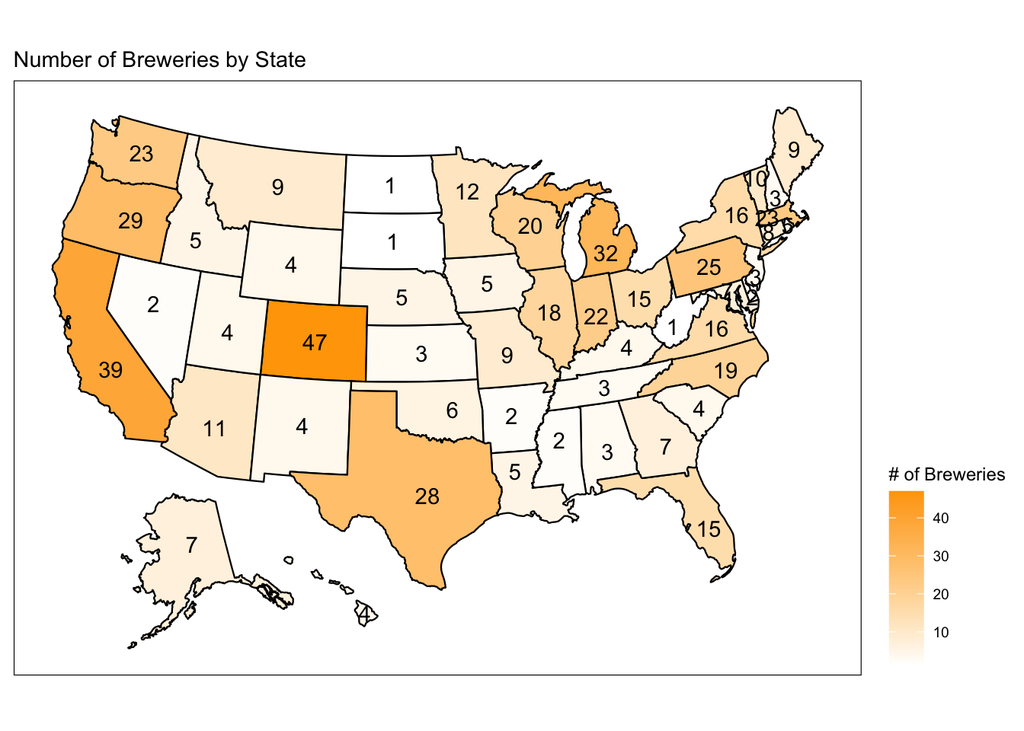

```r
breweryDataOrig = as.data.frame(breweryDataOrig)

Breweries.in.each.state = count(breweryDataOrig$State)
names(Breweries.in.each.state)[1] <- "state"
Breweries.in.each.state$state <-
  str_replace_all(string=Breweries.in.each.state$state,
                  pattern=" ", repl="")

centroid_labels <-
  utils::read.csv(system.file("extdata",
                              paste0("us_", "states", "_centroids.csv"),
                              package = "usmap"), stringsAsFactors = FALSE)

labels <-
  merge(x = centroid_labels,
        y = Breweries.in.each.state,
        by.x = "abbr",
        by.y = "state",
        all.x=TRUE)

names(labels)[6] <- "breweries_count"

plot_usmap(data = Breweries.in.each.state, values = "freq", labels=FALSE) +
  scale_fill_continuous(low = "white",
                        high = "orange",
                        name = "# of Breweries",
                        label = scales::comma) +
  theme(legend.position = "right") +
  theme(panel.background = element_rect(colour = "black")) +
  labs(title = "Number of Breweries by State") +
  geom_text(data = labels,
            ggplot2::aes(x = x, y = y,
            label = scales::number(breweries_count,accuracy = 1)),
            color = "black")
```

### 2. Merge beer data with the breweries data. Print the first 6 observations and the last six observations to check the merged file.

Beer and breweries data are merged using Brewery_ID as an index.

Below are first and last six observations on the merged beer dataset.

```r
mergedBeerData <- merge(x = beerDataOrig, y = breweryDataOrig,
                  by.x = "Brewery_id", by.y = "Brew_ID", all = TRUE)

names(mergedBeerData)[names(mergedBeerData)=="Name.x"] <- "Beer_name"
names(mergedBeerData)[names(mergedBeerData)=="Name.y"] <- "Brewery_name"

head(mergedBeerData)
```

```
##   Brewery_id     Beer_name Beer_ID   ABV IBU
## 1          1  Get Together    2692 0.045  50
## 2          1 Maggie's Leap    2691 0.049  26
## 3          1    Wall's End    2690 0.048  19
## 4          1       Pumpion    2689 0.060  38
## 5          1    Stronghold    2688 0.060  25
## 6          1   Parapet ESB    2687 0.056  47
##                                 Style Ounces       Brewery_name        City
## 1                        American IPA     16 NorthGate Brewing  Minneapolis
## 2                  Milk / Sweet Stout     16 NorthGate Brewing  Minneapolis
## 3                   English Brown Ale     16 NorthGate Brewing  Minneapolis
## 4                         Pumpkin Ale     16 NorthGate Brewing  Minneapolis
## 5                     American Porter     16 NorthGate Brewing  Minneapolis
## 6 Extra Special / Strong Bitter (ESB)     16 NorthGate Brewing  Minneapolis
##   State
## 1    MN
## 2    MN
## 3    MN
## 4    MN
## 5    MN
## 6    MN
```

```r
tail(mergedBeerData)
```

```
##      Brewery_id                 Beer_name Beer_ID   ABV IBU
## 2405        556             Pilsner Ukiah      98 0.055  NA
## 2406        557  Heinnieweisse Weissebier      52 0.049  NA
## 2407        557           Snapperhead IPA      51 0.068  NA
## 2408        557         Moo Thunder Stout      50 0.049  NA
## 2409        557         Porkslap Pale Ale      49 0.043  NA
## 2410        558 Urban Wilderness Pale Ale      30 0.049  NA
##                        Style Ounces                  Brewery_name          City
## 2405         German Pilsener     12         Ukiah Brewing Company         Ukiah
## 2406              Hefeweizen     12       Butternuts Beer and Ale Garrattsville
## 2407            American IPA     12       Butternuts Beer and Ale Garrattsville
## 2408      Milk / Sweet Stout     12       Butternuts Beer and Ale Garrattsville
## 2409 American Pale Ale (APA)     12       Butternuts Beer and Ale Garrattsville
## 2410        English Pale Ale     12 Sleeping Lady Brewing Company     Anchorage
##      State
## 2405    CA
## 2406    NY
## 2407    NY
## 2408    NY
## 2409    NY
## 2410    AK
```

### 3. Address the missing values in each column.

There are missing/empty values in three columns:

- ABV: 62 values missing
- IBU: 1,005 values missing, and
- Sty: 5 values missing

Totaling in 1,007 rows with missing value.

```r
mergedBeerData$Style <-
  lapply(mergedBeerData$Style,
         function(x) if(identical(x,"")) NA else x)


sapply(mergedBeerData, function(x) sum(is.na(x)))
```

```
##   Brewery_id    Beer_name      Beer_ID          ABV          IBU        Style
##            0            0            0           62         1005            5
##       Ounces Brewery_name         City        State
##            0            0            0            0
```

```r
row.has.na <- apply(mergedBeerData, 1, function(x){any(is.na(x))})
sum(row.has.na)
```

```
## [1] 1007
```

```r
# Filtered Merged Data
mergedBeerData.filtered <- mergedBeerData[!row.has.na,]

nrow(mergedBeerData.filtered)
```

```
## [1] 1403
```

### 4.Compute the median alcohol content and international bitterness unit for each state. Plot a bar chart to compare.

The median of Alcohol By Volume (ABV) and International Bitterness Units (IBU) for each state as shown below.

From the bar charts, Maine has the highest number for both ABV (0.067 or 6.7%) and IBU (61 unit).

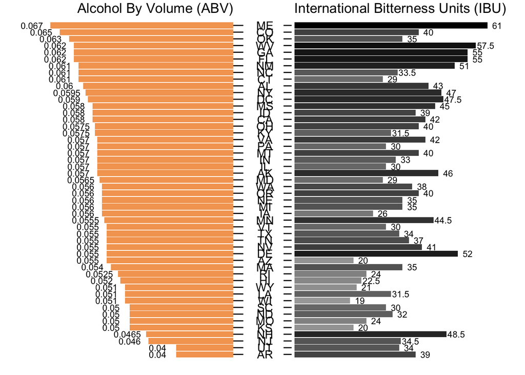

```r
medianData <- aggregate(mergedBeerData.filtered[, 4:5], list(mergedBeerData.filtered$State), median)
names(medianData)[names(medianData)=="Group.1"] <- "State"

g.mid <- ggplot(medianData,aes(x=1, y = reorder(State,ABV))) +
  geom_text(aes(label=State)) +
  geom_segment(aes(x=0.94,xend=0.96,yend=State)) +
  geom_segment(aes(x=1.04,xend=1.062,yend=State)) +
  ggtitle("") +
  ylab(NULL) +
  scale_x_continuous(expand=c(0,0),limits=c(0.94,1.062)) +
  theme(axis.title=element_blank(),
        panel.grid=element_blank(),
        axis.text.y=element_blank(),
        axis.ticks.y=element_blank(),
        panel.background=element_blank(),
        axis.text.x=element_text(color=NA),
        axis.ticks.x=element_line(color=NA),
        plot.margin = unit(c(1,-1,1,-1), "mm"))

g1 <- ggplot(data = medianData, aes(x = reorder(State,ABV), y = ABV, label = ABV)) +
  geom_bar(stat = "identity", fill = "sandybrown") +
  ggtitle("Alcohol By Volume (ABV)") +
  geom_text(aes(y = ABV+0.004),
            size = 3,
            vjust = .5) +
  theme(panel.background = element_blank(),
        axis.title.x = element_blank(),
        axis.text.x=element_text(color=NA),
        axis.ticks.x=element_line(color=NA),
        axis.title.y = element_blank(),
        axis.text.y = element_blank(),
        axis.ticks.y = element_blank(),
        legend.position = "none",
        plot.title = element_text(hjust = 1),
        plot.margin = unit(c(1,0,1,0), "mm")) +
  scale_y_reverse() +
  coord_flip(ylim = c(0.075,0.03))

g2 <- ggplot(data = medianData, aes(x = reorder(State,ABV), y = IBU, fill = IBU, label = IBU)) +
  xlab(NULL) +
  geom_bar(stat = "identity") +
  ggtitle("International Bitterness Units (IBU)") +
  geom_text(aes(y = IBU+3),
            size = 3,
            vjust = .5) +
  scale_fill_gradient2(low = "grey25",
                       high = "black",
                       name = "IBU") +
  theme(panel.background = element_blank(),
        axis.title.x = element_blank(),
        axis.text.x=element_text(color=NA),
        axis.ticks.x=element_line(color=NA),
        axis.title.y = element_blank(),
        axis.text.y = element_blank(),
        axis.ticks.y = element_blank(),
        legend.position = "none",
        plot.margin = unit(c(1,5,1,0), "mm")) +
  coord_flip(ylim = c(5,65))

gg1 <- ggplot_gtable(ggplot_build(g1))
gg2 <- ggplot_gtable(ggplot_build(g2))
gg.mid <- ggplot_gtable(ggplot_build(g.mid))

grid.arrange(gg1,gg.mid,gg2,ncol=3,widths=c(4/9,1/9,4/9))
```

Combined the two bar charts together with radial stacked bar chart.

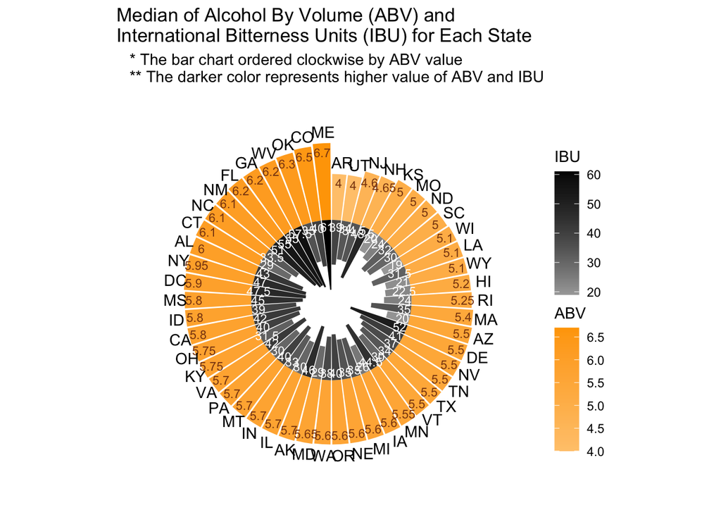

```r
medianData %>%
  ggplot(aes(x = reorder(State,ABV))) +
  geom_col(aes(y = ABV*1000, fill = ABV*100)) +
  scale_fill_gradient2(low = "white",
                       high = "orange",
                       name = "ABV") +
  geom_text(aes(y = ABV*1000-8, label = round(ABV*100, 3)), color = "chocolate4", size = 3) +
  new_scale_fill() +
  geom_col(aes(y = -IBU, fill = IBU)) +
  scale_fill_gradient2(low = "grey25",
                       high = "black",
                       name = "IBU") +
  geom_text(aes(y = -6, label = round(IBU, 3)), color = "white", size = 3) +
  geom_text(aes(y = ABV*1000+10, label = State)) +
  scale_y_continuous(limits = c(-70, 80)) +
  coord_polar() +
  theme_void() +
  labs(title = "Median of Alcohol By Volume (ABV) and\nInternational Bitterness Units (IBU) for Each State",
       subtitle = "   * The bar chart ordered clockwise by ABV value\n   ** The darker color represents higher value of ABV and IBU")
```

### 5. Which state has the maximum alcoholic (ABV) beer? Which state has the most bitter (IBU) beer?

When consider the median value of ABV and IBU, Maine has the highest number for both ABV (0.067 or 6.7%) and IBU (61 unit).

```r
# arrange by ABV in descending order, print state for first observation
orderedABVmedian <- medianData %>% arrange(desc(ABV))
orderedABVmedian[1,]$State
```

```
## [1] " ME"
```

```r
orderedIBUmedian <- medianData %>% arrange(desc(IBU))
orderedIBUmedian[1,]$State
```

```
## [1] " ME"
```

But when consider individual beer,

- Kentucky has the highest number for ABV which is 0.125 or 12.5% from London Valling Beer and
- Oregon has the highest value for IBU which is 138 unit from Bitter Bitch Imperial IPA.

```r
# arrange by ABV in descending order, print state for first observation
orderedABV <- mergedBeerData.filtered %>% arrange(desc(ABV))
orderedABV[1,]
```

```
##   Brewery_id      Beer_name Beer_ID   ABV IBU              Style Ounces
## 1          2 London Balling    2685 0.125  80 English Barleywine     16
##                Brewery_name       City State
## 1 Against the Grain Brewery Louisville    KY
```

```r
orderedIBU <- mergedBeerData.filtered %>% arrange(desc(IBU))
orderedIBU[1,]
```

```
##   Brewery_id                 Beer_name Beer_ID   ABV IBU
## 1        375 Bitter Bitch Imperial IPA     980 0.082 138
##                            Style Ounces            Brewery_name    City State
## 1 American Double / Imperial IPA     12 Astoria Brewing Company Astoria    OR
```

### 6. Comment on the summary statistics and distribution of the ABV variable.

```r
mergedBeerData.filtered %>%
    summarize(mean=mean(ABV),
              sd=sd(ABV),
              median=median(ABV),
              range=max(ABV)-min(ABV),
              min(ABV),
              max(ABV),
              IQR=IQR(ABV))
```

```
##         mean         sd median range min(ABV) max(ABV)   IQR
## 1 0.05991875 0.01358475  0.057 0.098    0.027    0.125 0.018
```

### 7. Is there an apparent relationship between the bitterness of the beer and its alcoholic content? Draw a scatter plot. Make your best judgment of a relationship and EXPLAIN your answer.

From the scatter plot with a regression line, there is a positive correlation between a beer’s ABV and its IBU. There is strong evidence at the alpha = .05 level of significance to suggest that there is a linearly correlated relationship between a beer’s ABV and its IBU (p-value <.0001), with Pearson’s Correlation Coefficient = 0.67 and r-square = 0.45.

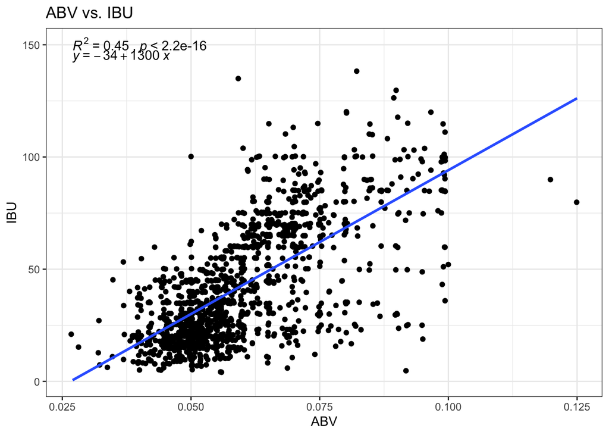

```r
mergedBeerData.filtered %>%
  ggplot(aes(x = ABV,y = IBU)) +
  geom_jitter() +
  ggtitle("ABV vs. IBU") +
  geom_smooth(method="lm", se=F) +
  stat_cor(label.y = 150,
           aes(label = paste(..rr.label..,
                             ..p.label..,
                             sep = "~`,`~"))) +
  stat_regline_equation(label.y = 145) +
  theme_bw()
```

```r
cor.test(mergedBeerData.filtered$ABV,mergedBeerData.filtered$IBU)
```

```
##
##  Pearson's product-moment correlation
##
## data:  mergedBeerData.filtered$ABV and mergedBeerData.filtered$IBU
## t = 33.848, df = 1401, p-value < 2.2e-16
## alternative hypothesis: true correlation is not equal to 0
## 95 percent confidence interval:
##  0.6408842 0.6985369
## sample estimates:
##       cor
## 0.6707224
```

### 8. Budweiser would also like to investigate the difference with respect to IBU and ABV between IPAs (India Pale Ales) and other types of Ale (any beer with “Ale” in its name other than IPA). You decide to use KNN classification to investigate this relationship Provide statistical evidence one way or the other.

*You can of course assume your audience is comfortable with percentages … KNN is very easy to understand conceptually.*

```r
mergedBeerData.filtered$AleStyle <-
  ifelse(grepl("IPA", mergedBeerData.filtered$Style, fixed = TRUE),"IPA",
         ifelse(grepl("Ale", mergedBeerData.filtered$Style, fixed = TRUE),"Ale","Other"))

mergedBeerData.filtered$AleByName <-
  ifelse(grepl("India Pale Ale", mergedBeerData.filtered$Beer_name, fixed = TRUE),"IPA",
         ifelse(grepl("IPA", mergedBeerData.filtered$Beer_name, fixed = TRUE),"IPA",
                ifelse(grepl("Ale", mergedBeerData.filtered$Beer_name, fixed = TRUE),"Ale","Other")))

aleBeerFiltered <- mergedBeerData.filtered %>% filter(AleByName == "IPA" | AleByName == "Ale")

set.seed(4)
splitPerc = .7

trainIndices = sample(1:dim(aleBeerFiltered)[1], round(splitPerc * dim(aleBeerFiltered)[1]))
beerTrain = aleBeerFiltered[trainIndices,]
beerTest = aleBeerFiltered[-trainIndices,]

# run knn
classifications = knn(beerTrain[,4:5], beerTest[,4:5], beerTrain$AleByName, k = 5, prob = TRUE)
summary(classifications)
```

```
## Ale IPA
## 104  77
```

```r
# Confusion Matrix
table(beerTest$AleByName, classifications)
```

```
##      classifications
##       Ale IPA
##   Ale  89  17
##   IPA  15  60
```

```r
CM = confusionMatrix(table(beerTest$AleByName, classifications))
CM
```

```
## Confusion Matrix and Statistics
##
##      classifications
##       Ale IPA
##   Ale  89  17
##   IPA  15  60
##
##                Accuracy : 0.8232
##                  95% CI : (0.7597, 0.8758)
##     No Information Rate : 0.5746
##     P-Value [Acc > NIR] : 9.345e-13
##
##                   Kappa : 0.6371
##
##  Mcnemar's Test P-Value : 0.8597
##
##             Sensitivity : 0.8558
##             Specificity : 0.7792
##          Pos Pred Value : 0.8396
##          Neg Pred Value : 0.8000
##              Prevalence : 0.5746
##          Detection Rate : 0.4917
##    Detection Prevalence : 0.5856
##       Balanced Accuracy : 0.8175
##
##        'Positive' Class : Ale
##
```

### 9. Knock their socks off! Find one other useful inference from the data that you feel Budweiser may be able to find value in. You must convince them why it is important and back up your conviction with appropriate statistical evidence.

```r
set.seed(4)
splitPerc = .7

trainIndices.allType = sample(1:dim(mergedBeerData.filtered)[1], round(splitPerc * dim(mergedBeerData.filtered)[1]))
beerTrain.allType = mergedBeerData.filtered[trainIndices.allType,]
beerTest.allType = mergedBeerData.filtered[-trainIndices.allType,]

# run knn
classifications = knn(beerTrain.allType[,4:5], beerTest.allType[,4:5], beerTrain.allType$AleByName, k = 5, prob = TRUE)
summary(classifications)
```

```
##   Ale   IPA Other
##    83    79   259
```

```r
# Confusion Matrix
table(beerTest.allType$AleByName, classifications)
```

```
##        classifications
##         Ale IPA Other
##   Ale    30   6    67
##   IPA     9  44    30
##   Other  44  29   162
```

```r
CM.allType = confusionMatrix(table(beerTest.allType$AleByName, classifications))
CM.allType
```

```
## Confusion Matrix and Statistics
##
##        classifications
##         Ale IPA Other
##   Ale    30   6    67
##   IPA     9  44    30
##   Other  44  29   162
##
## Overall Statistics
##
##                Accuracy : 0.5606
##                  95% CI : (0.5117, 0.6086)
##     No Information Rate : 0.6152
##     P-Value [Acc > NIR] : 0.9903
##
##                   Kappa : 0.2309
##
##  Mcnemar's Test P-Value : 0.1458
##
## Statistics by Class:
##
##                      Class: Ale Class: IPA Class: Other
## Sensitivity             0.36145     0.5570       0.6255
## Specificity             0.78402     0.8860       0.5494
## Pos Pred Value          0.29126     0.5301       0.6894
## Neg Pred Value          0.83333     0.8964       0.4785
## Prevalence              0.19715     0.1876       0.6152
## Detection Rate          0.07126     0.1045       0.3848
## Detection Prevalence    0.24466     0.1971       0.5582
## Balanced Accuracy       0.57273     0.7215       0.5874
```